# Data 607 Final Project

Warner Alexis

2023-12-10

## Hospital Readmission Reduction

The center for Medicare and Medicaid Services begun to reduce payment to Hospitals for excessive readmissions on October 1rst 2012 as part of the Affordable Care Act. Hospitals’ mission switches strategies to reduce rehospitalization rate and improves quality care so patients don’t come back within 30 days readmission. There are several strategies implemented to enable the process but, the use of data analytics has been indispensable to reduction of readmission rate. Warchol et al. said: “Data analytics can be used to improve clinical operations, watch for care patterns, and identify readmission risk.” He acknowledges that other researcher like Monga suggested that hospitals have the ability to design an analytical model to predict the likelihood of patients’ readmission on the basis of information collected in Electronic Health Records (EHR). The purpose of this project is to predict the hospital readmission from this data set in UC Irvine Machine Learning Repository called “Diabetes 130-US hospitals for years 1999-2008”.

Data Source: https://archive.ics.uci.edu/dataset/296/diabetes+130-us+hospitals+for+years+1999-2008

Readmission is considered when patient return to hospital 30 days after his first admission.

```r
library(tidyverse)
```

```r
library(ggplot2)
library(skimr)
library(htmlTable)
#library(glmnet)
library(caret)
#library(DMwR)
library(corrplot)
# Load teh data set
# read the hospital data
diabetic <- read.csv("https://raw.githubusercontent.com/joewarner89/CUNY-607/main/Final%20Project/diabetic_data.csv", stringsAsFactors = F)
data_info <- read.csv("https://raw.githubusercontent.com/joewarner89/CUNY-607/main/Final%20Project/IDS_mapping.csv", stringsAsFactors = F)

# Let map some column
admin <- data_info %>% select(1,2) %>% stats::na.omit()
disch <- data_info %>% select(3,4) %>% na.omit()
admin_sc <- data_info %>% select(5,6) %>% na.omit()

# Remapping the column name with id

diabetic <- diabetic %>% inner_join(admin,by =  "admission_type_id") %>%
  inner_join(disch,by = "discharge_disposition_id") %>%
  inner_join(admin_sc,by = "admission_source_id") %>%
  select(1:5,7,admission_type_name,discharge_disposition_id,discharge_disposition_name
        ,admission_source_id,admission_source_name,9:51)
# get a look on how the data set work
skim(diabetic)
```

Data summary

| Name | diabetic |
| --- | --- |
| Number of rows | 101766 |
| Number of columns | 52 |
| _______________________ |  |
| Column type frequency: |  |
| character | 39 |
| numeric | 13 |
| ________________________ |  |
| Group variables | None |

**Variable type: character**

| skim_variable | n_missing | complete_rate | min | max | empty | n_unique | whitespace |
| --- | --- | --- | --- | --- | --- | --- | --- |
| race | 0 | 1 | 1 | 15 | 0 | 6 | 0 |
| gender | 0 | 1 | 4 | 15 | 0 | 3 | 0 |
| age | 0 | 1 | 6 | 8 | 0 | 10 | 0 |
| admission_type_name | 0 | 1 | 4 | 13 | 0 | 8 | 0 |
| discharge_disposition_name | 0 | 1 | 4 | 105 | 0 | 26 | 0 |
| admission_source_name | 0 | 1 | 4 | 58 | 0 | 17 | 0 |
| payer_code | 0 | 1 | 1 | 2 | 0 | 18 | 0 |
| medical_specialty | 0 | 1 | 1 | 36 | 0 | 73 | 0 |
| diag_1 | 0 | 1 | 1 | 6 | 0 | 717 | 0 |
| diag_2 | 0 | 1 | 1 | 6 | 0 | 749 | 0 |
| diag_3 | 0 | 1 | 1 | 6 | 0 | 790 | 0 |
| max_glu_serum | 0 | 1 | 4 | 4 | 0 | 4 | 0 |
| A1Cresult | 0 | 1 | 2 | 4 | 0 | 4 | 0 |
| metformin | 0 | 1 | 2 | 6 | 0 | 4 | 0 |
| repaglinide | 0 | 1 | 2 | 6 | 0 | 4 | 0 |
| nateglinide | 0 | 1 | 2 | 6 | 0 | 4 | 0 |
| chlorpropamide | 0 | 1 | 2 | 6 | 0 | 4 | 0 |
| glimepiride | 0 | 1 | 2 | 6 | 0 | 4 | 0 |
| acetohexamide | 0 | 1 | 2 | 6 | 0 | 2 | 0 |
| glipizide | 0 | 1 | 2 | 6 | 0 | 4 | 0 |
| glyburide | 0 | 1 | 2 | 6 | 0 | 4 | 0 |
| tolbutamide | 0 | 1 | 2 | 6 | 0 | 2 | 0 |
| pioglitazone | 0 | 1 | 2 | 6 | 0 | 4 | 0 |
| rosiglitazone | 0 | 1 | 2 | 6 | 0 | 4 | 0 |
| acarbose | 0 | 1 | 2 | 6 | 0 | 4 | 0 |
| miglitol | 0 | 1 | 2 | 6 | 0 | 4 | 0 |
| troglitazone | 0 | 1 | 2 | 6 | 0 | 2 | 0 |
| tolazamide | 0 | 1 | 2 | 6 | 0 | 3 | 0 |
| examide | 0 | 1 | 2 | 2 | 0 | 1 | 0 |
| citoglipton | 0 | 1 | 2 | 2 | 0 | 1 | 0 |
| insulin | 0 | 1 | 2 | 6 | 0 | 4 | 0 |
| glyburide.metformin | 0 | 1 | 2 | 6 | 0 | 4 | 0 |
| glipizide.metformin | 0 | 1 | 2 | 6 | 0 | 2 | 0 |
| glimepiride.pioglitazone | 0 | 1 | 2 | 6 | 0 | 2 | 0 |
| metformin.rosiglitazone | 0 | 1 | 2 | 6 | 0 | 2 | 0 |
| metformin.pioglitazone | 0 | 1 | 2 | 6 | 0 | 2 | 0 |
| change | 0 | 1 | 2 | 2 | 0 | 2 | 0 |
| diabetesMed | 0 | 1 | 2 | 3 | 0 | 2 | 0 |
| readmitted | 0 | 1 | 2 | 3 | 0 | 3 | 0 |

**Variable type: numeric**

| skim_variable | n_missing | complete_rate | mean | sd | p0 | p25 | p50 | p75 | p100 | hist |
| --- | --- | --- | --- | --- | --- | --- | --- | --- | --- | --- |
| encounter_id | 0 | 1 | 165201645.62 | 102640295.98 | 12522 | 84961194 | 152388987 | 230270888 | 443867222 | ▆▇▅▂▂ |
| patient_nbr | 0 | 1 | 54330400.69 | 38696359.35 | 135 | 23413221 | 45505143 | 87545950 | 189502619 | ▇▆▆▁▁ |
| admission_type_id | 0 | 1 | 2.02 | 1.45 | 1 | 1 | 1 | 3 | 8 | ▇▂▁▁▁ |
| discharge_disposition_id | 0 | 1 | 3.72 | 5.28 | 1 | 1 | 1 | 4 | 28 | ▇▁▁▁▁ |
| admission_source_id | 0 | 1 | 5.75 | 4.06 | 1 | 1 | 7 | 7 | 25 | ▅▇▁▁▁ |
| time_in_hospital | 0 | 1 | 4.40 | 2.99 | 1 | 2 | 4 | 6 | 14 | ▇▅▂▁▁ |
| num_lab_procedures | 0 | 1 | 43.10 | 19.67 | 1 | 31 | 44 | 57 | 132 | ▃▇▅▁▁ |
| num_procedures | 0 | 1 | 1.34 | 1.71 | 0 | 0 | 1 | 2 | 6 | ▇▂▁▁▁ |
| num_medications | 0 | 1 | 16.02 | 8.13 | 1 | 10 | 15 | 20 | 81 | ▇▃▁▁▁ |
| number_outpatient | 0 | 1 | 0.37 | 1.27 | 0 | 0 | 0 | 0 | 42 | ▇▁▁▁▁ |
| number_emergency | 0 | 1 | 0.20 | 0.93 | 0 | 0 | 0 | 0 | 76 | ▇▁▁▁▁ |
| number_inpatient | 0 | 1 | 0.64 | 1.26 | 0 | 0 | 0 | 1 | 21 | ▇▁▁▁▁ |
| number_diagnoses | 0 | 1 | 7.42 | 1.93 | 1 | 6 | 8 | 9 | 16 | ▁▅▇▁▁ |

## Understanding the data set

According the UC Irvine, The dataset represents ten years (1999-2008) of clinical care at 130 US hospitals and integrated delivery networks. It includes over 50 features representing patient and hospital outcomes. Information was extracted from the database for encounters that satisfied the following criteria. (1) It is an inpatient encounter (a hospital admission). (2) It is a diabetic encounter, that is, one during which any kind of diabetes was entered into the system as a diagnosis. (3) The length of stay was at least 1 day and at most 14 days. (4) Laboratory tests were performed during the encounter. (5) Medications were administered during the encounter.

There is a lot of categorical values that are significant to a hospital encounter and readmission in this data set. I need to remove any undocumented observations and mark them NA so later on it doesn’t affect the classification model.

```
##               encounter_id                patient_nbr
##                          0                          0
##                       race                     gender
##                       2273                          0
##                        age          admission_type_id
##                          0                          0
##        admission_type_name   discharge_disposition_id
##                          0                          0
## discharge_disposition_name        admission_source_id
##                          0                          0
##      admission_source_name           time_in_hospital
##                          0                          0
##                 payer_code          medical_specialty
##                      40256                      49949
##         num_lab_procedures             num_procedures
##                          0                          0
##            num_medications          number_outpatient
##                          0                          0
##           number_emergency           number_inpatient
##                          0                          0
##                     diag_1                     diag_2
##                         21                        358
##                     diag_3           number_diagnoses
##                       1423                          0
##              max_glu_serum                  A1Cresult
##                          0                          0
##                  metformin                repaglinide
##                          0                          0
##                nateglinide             chlorpropamide
##                          0                          0
##                glimepiride              acetohexamide
##                          0                          0
##                  glipizide                  glyburide
##                          0                          0
##                tolbutamide               pioglitazone
##                          0                          0
##              rosiglitazone                   acarbose
##                          0                          0
##                   miglitol               troglitazone
##                          0                          0
##                 tolazamide                    examide
##                          0                          0
##                citoglipton                    insulin
##                          0                          0
##        glyburide.metformin        glipizide.metformin
##                          0                          0
##   glimepiride.pioglitazone    metformin.rosiglitazone
##                          0                          0
##     metformin.pioglitazone                     change
##                          0                          0
##                diabetesMed                 readmitted
##                          0                          0
```

```
##               encounter_id                patient_nbr
##                          0                          0
##                       race                     gender
##                          0                          0
##                        age          admission_type_id
##                          0                          0
##        admission_type_name   discharge_disposition_id
##                          0                          0
## discharge_disposition_name        admission_source_id
##                          0                          0
##      admission_source_name           time_in_hospital
##                          0                          0
##                 payer_code          medical_specialty
##                          0                          0
##         num_lab_procedures             num_procedures
##                          0                          0
##            num_medications          number_outpatient
##                          0                          0
##           number_emergency           number_inpatient
##                          0                          0
##                     diag_1                     diag_2
##                          0                          0
##                     diag_3           number_diagnoses
##                          0                          0
##              max_glu_serum                  A1Cresult
##                          0                          0
##                  metformin                repaglinide
##                          0                          0
##                nateglinide             chlorpropamide
##                          0                          0
##                glimepiride              acetohexamide
##                          0                          0
##                  glipizide                  glyburide
##                          0                          0
##                tolbutamide               pioglitazone
##                          0                          0
##              rosiglitazone                   acarbose
##                          0                          0
##                   miglitol               troglitazone
##                          0                          0
##                 tolazamide                    examide
##                          0                          0
##                citoglipton                    insulin
##                          0                          0
##        glyburide.metformin        glipizide.metformin
##                          0                          0
##   glimepiride.pioglitazone    metformin.rosiglitazone
##                          0                          0
##     metformin.pioglitazone                     change
##                          0                          0
##                diabetesMed                 readmitted
##                          0                          0
```

```
## [1] 25926    52
```

According to our summary, some data columns have only unique categorical value. Single value columns need to be removed in the data set.

```r
diabetic %>% select(citoglipton,examide,troglitazone,glimepiride.pioglitazone,
                    metformin.rosiglitazone,acetohexamide,tolbutamide) %>%
  distinct()
```

```
##   citoglipton examide troglitazone glimepiride.pioglitazone
## 1          No      No           No                       No
##   metformin.rosiglitazone acetohexamide tolbutamide
## 1                      No            No          No
```

```r
#remove columns
diabetic$citoglipton <- NULL
diabetic$examide <- NULL
diabetic$troglitazone <- NULL
diabetic$glimepiride.pioglitazone <- NULL
diabetic$acetohexamide <- NULL
diabetic$metformin.rosiglitazone <- NULL
diabetic$tolbutamide <- NULL

dim(diabetic)
```

```
## [1] 25926    45
```

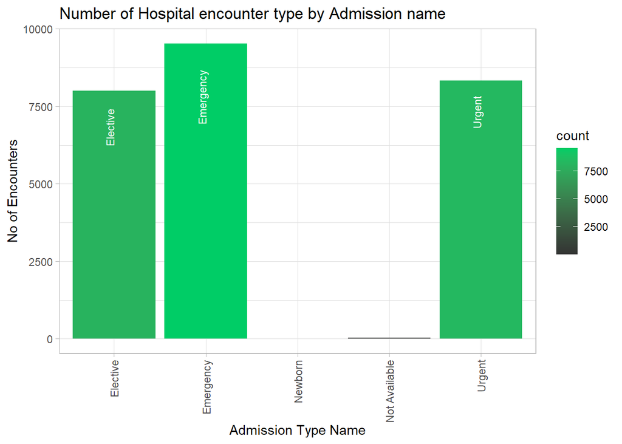

```r
#### Number of encounter type by Admission name
diabetic %>%  group_by(admission_type_name) %>% summarise(count = n()) %>% group_by(admission_type_name) %>%

  ggplot( mapping = aes(x=admission_type_name, y=count, fill=count))+
  geom_bar(position = "dodge", stat="identity")+
  scale_fill_gradient(low = "grey20", high = "springgreen3")+
  theme_light()+
  theme(axis.text.x = element_text(angle = 90, vjust = 0.5, hjust = 1))+labs(height=10, width=5)+
  geom_text(aes(label = admission_type_name),color="white",hjust= 1.5, vjust = 0, size = 3, angle = 90, position = position_dodge(width = 1)) + labs(title = "Number of Hospital encounter type by Admission name", x = "Admission Type Name", y = "No of Encounters")
```

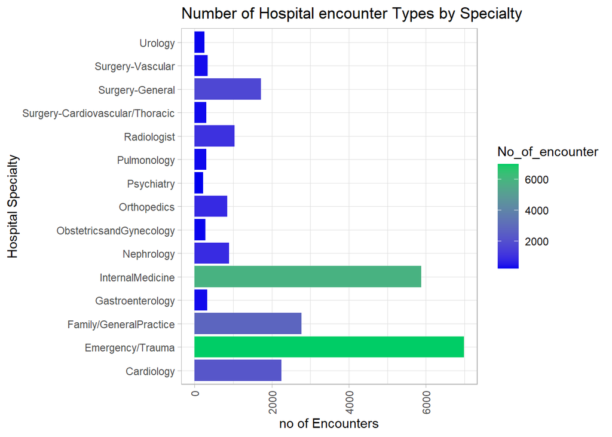

```r
# number of encounters by
diabetic  %>% group_by(specialty = medical_specialty) %>%
  summarise(No_of_encounter = n()) %>%
  arrange(desc(No_of_encounter)) %>%
  top_n(15, wt = No_of_encounter) %>%
  ggplot(aes(x = specialty, y = No_of_encounter, fill = No_of_encounter)) +
  geom_bar(position = "dodge", stat="identity")+
  scale_fill_gradient(low = "blue2", high = "springgreen3")+
  theme_light()+
  theme(axis.text.x = element_text(angle = 90, vjust = 0.5, hjust = 1))+labs(height=10, width=5)+
  coord_flip() + labs(title = "Number of Hospital encounter Types by Specialty", x = "Hospital Specialty", y = "no of Encounters")
```

```r
# remove the icd 9 code to reveal more inormation

diabetic$diag_1 <- str_replace_all(diabetic$diag_1, "[[:punct:]]", "")
diabetic$diag_2 <- str_replace_all(diabetic$diag_2, "[[:punct:]]", "")
diabetic$diag_3 <- str_replace_all(diabetic$diag_3, "[[:punct:]]", "")

# read the icd 9 code from
icd_9 <- read.delim("https://raw.githubusercontent.com/joewarner89/CUNY-607/main/Final%20Project/icd9.txt",stringsAsFactors = F) %>% rename(diag_1 = 1,Short_desc = 3)
```

The risk of developing pneumonia increase with diabetes. According to healthline.com, diabetes weaken your immune system. In our data set, we have 908 Hospital visits that result in a claim for pneumonia and about 185 for population ages 18 years and older that was diagnosed with uncontrolled diabetes. We may have more patients that fits these diagnosis.

The data do not contain any diagnosis name and group name. We download the ICD 9 code from CMS data and major name was collected in this link https://juniperpublishers.com/ctbeb/CTBEB.MS.ID.555715.php

The next step is to create diagnosis category to capture all major events. see picture below:

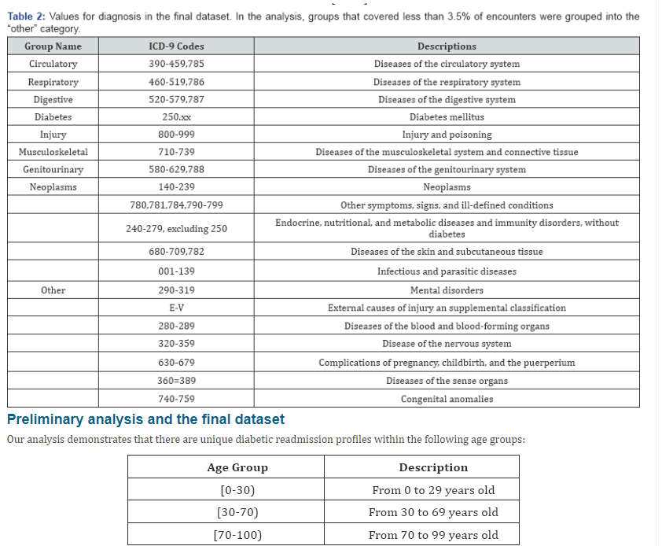

Main Group Name for ICD 9

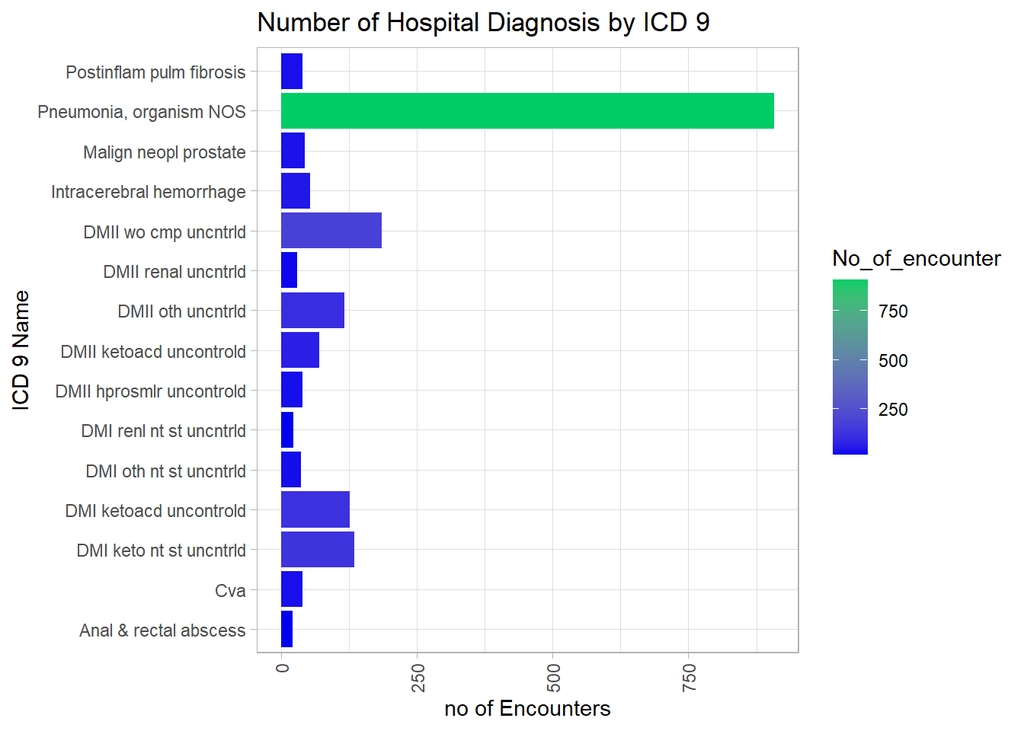

```r
# look at the main diagnosis for

diabetic   %>%
  inner_join(icd_9,by="diag_1")  %>% select(encounter_id,diag_1,Short_desc) %>%
  group_by(Short_desc) %>%  summarize(No_of_encounter = n()) %>%
  arrange(desc(No_of_encounter)) %>%
  top_n(15, wt = No_of_encounter) %>%
  ggplot(aes(x = Short_desc, y = No_of_encounter, fill = No_of_encounter)) +
  geom_bar(position = "dodge", stat="identity")+
  scale_fill_gradient(low = "blue2", high = "springgreen3")+
  theme_light()+
  theme(axis.text.x = element_text(angle = 90, vjust = 0.5, hjust = 1))+labs(height=10, width=5)+
  coord_flip() + labs(title = "Number of Hospital Diagnosis by ICD 9", x = "ICD 9 Name", y = "no of Encounters")
```

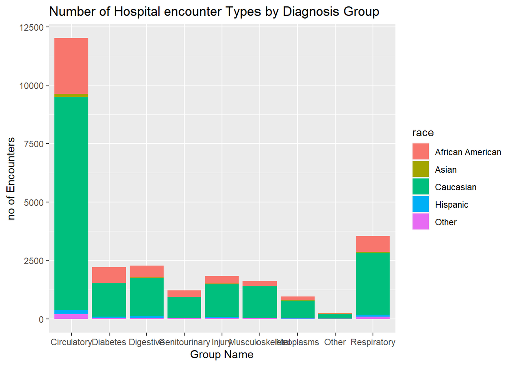

```r
# Diabetes Poor controls
diag_cate <- c("2511", "2512", "24901", "24930", "24931", "24941", "24951"," 24961", '24971', "24981", "24991", "25002", "25003", "25030", "25031",
               "25032", "25033", "25042", "25043,", "25052", "25053", "25062", "25063", "25072", "25073", "25082", "25083", "25092", "25093")

# Create diagnosis table
data <- mutate(diabetic, diagnosis =
         ifelse(str_detect(diag_1, "V") | str_detect(diag_1, "E"),"Other",
                # disease codes starting with V or E are in “other” category;
                ifelse(str_detect(diag_1, "250"), "Diabetes",
                       ifelse((as.integer(diag_1) %in% diag_cate & as.integer(diag_1) <= 459) | as.integer(diag_1) == 785, "Circulatory",
                              ifelse((as.integer(diag_1) >= 460 & as.integer(diag_1) <= 519) | as.integer(diag_1) == 786, "Respiratory",
                                     ifelse((as.integer(diag_1) >= 520 & as.integer(diag_1) <= 579) | as.integer(diag_1) == 787, "Digestive",
                                            ifelse((as.integer(diag_1) >= 580 & as.integer(diag_1) <= 629) | as.integer(diag_1) == 788, "Genitourinary",
                                                   ifelse((as.integer(diag_1) >= 140 & as.integer(diag_1) <= 239), "Neoplasms",
                                                          ifelse((as.integer(diag_1) >= 710 & as.integer(diag_1) <= 739), "Musculoskeletal",
                                                                 ifelse((as.integer(diag_1) >= 800 & as.integer(diag_1) <= 999), "Injury",
                                                                        "Circulatory"))))))))))


# Group Name by encounter count

data %>%  group_by(diagnosis,race) %>% summarise(count = n()) %>% group_by(diagnosis) %>%
  ggplot(aes(x =diagnosis, y = count, fill = race)) +
  geom_col() +
   labs(title = "Number of Hospital encounter Types by Diagnosis Group", x = "Group Name", y = "no of Encounters")
```

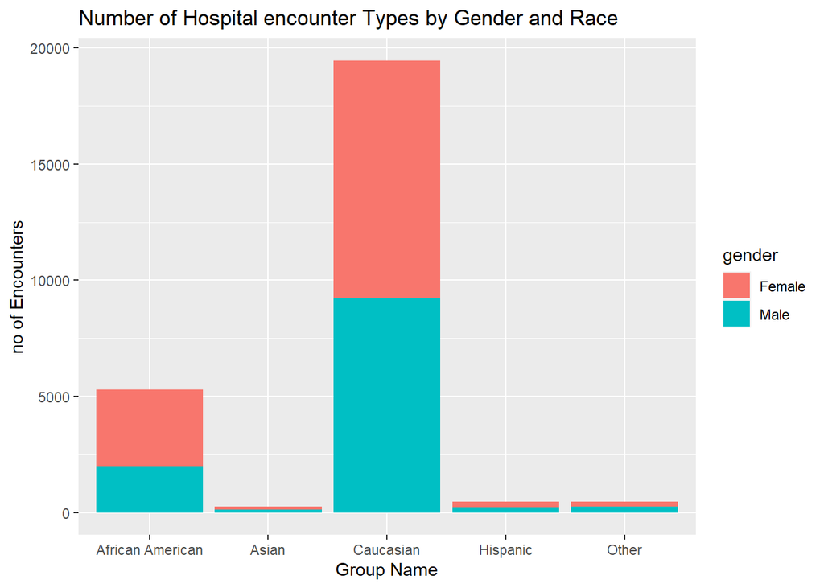

```r
# Number of men and women affected by diabetes
data %>%  group_by(race,gender) %>% summarise(count = n()) %>%  arrange(desc(count)) %>%
  ggplot(aes(x =race, y = count, fill = gender)) +
  geom_col() +
  labs(title = "Number of Hospital encounter Types by Gender and Race", x = "Group Name", y = "no of Encounters")
```

```r
# gender stats

gender_stat <- data %>%  group_by(race,gender) %>% summarise(count = n()) %>%  arrange(desc(count))
htmlTable(gender_stat)
```

|  | race | gender | count |
| --- | --- | --- | --- |
| 1 | Caucasian | Female | 10221 |
| 2 | Caucasian | Male | 9240 |
| 3 | African American | Female | 3307 |
| 4 | African American | Male | 1980 |
| 5 | Other | Male | 247 |
| 6 | Hispanic | Female | 237 |
| 7 | Hispanic | Male | 227 |
| 8 | Other | Female | 218 |
| 9 | Asian | Male | 130 |
| 10 | Asian | Female | 119 |

Diabetes mellitus or diabetes disproportionately affects minority populations. Most patients who poor control over their diabetes treatment face circulatory issues. In the data set, both caucasian and African american have the high number of circulatory diagnosis. There are more women caucasian that are diagnosed with diabetes more than every ethnic group.

## Multivariate and Univariate Analysis

We modify the input of some the features to scale the data set. I make change to some categorical values. This data set has more than 15 categorical values. It is very useful to understand the impact of each variables in real life. Medication play a big part of treatments for Diabetes. Some of the features present a challenge due to the way they were created. Variables with low variances are not reliable for statistical modeling.

We combine all the low variance columns to add more variances to the data and preserve the information. Based on the initial graph we did, we need to remove outliers.

```r
# reassign data set
lib <- data

## Removing duplicate patients encounter
lib <- lib[!duplicated(lib$patient_nbr),]

# Change some categorical data to numerical
# recategorize the column age
lib$age <- ifelse(lib$age == "[0-10)",  0, lib$age);
lib$age <- ifelse(lib$age == "[10-20)", 10, lib$age);
lib$age <- ifelse(lib$age == "[20-30)", 20, lib$age);
lib$age <- ifelse(lib$age == "[30-40)", 30, lib$age);
lib$age <- ifelse(lib$age == "[40-50)", 40, lib$age);
lib$age <- ifelse(lib$age == "[50-60)", 50, lib$age);
lib$age <- ifelse(lib$age == "[60-70)", 60, lib$age);
lib$age <- ifelse(lib$age == "[70-80)", 70, lib$age);
lib$age <- ifelse(lib$age == "[80-90)", 80, lib$age);
lib$age <- ifelse(lib$age == "[90-100)", 90, lib$age);

# Change categorical values
lib$max_glu_serum <- ifelse(lib$max_glu_serum == "None",  0, lib$max_glu_serum);
lib$max_glu_serum <- ifelse(lib$max_glu_serum == "Norm",  100, lib$max_glu_serum);
lib$max_glu_serum <- ifelse(lib$max_glu_serum == ">200",  200, lib$max_glu_serum);
lib$max_glu_serum <- ifelse(lib$max_glu_serum == ">300",  300, lib$max_glu_serum);

lib$A1Cresult <- ifelse(lib$A1Cresult == "None",  0, lib$A1Cresult);
lib$A1Cresult <- ifelse(lib$A1Cresult == "Norm",  5, lib$A1Cresult);
lib$A1Cresult <- ifelse(lib$A1Cresult == ">7",    7, lib$A1Cresult);
lib$A1Cresult <- ifelse(lib$A1Cresult == ">8",    8, lib$A1Cresult);

lib$metformin <- ifelse(lib$metformin == 'No', 0 , lib$metformin);
lib$metformin <- ifelse(lib$metformin == 'Steady', 1 , lib$metformin);
lib$metformin <- ifelse(lib$metformin == 'Up', 2 , lib$metformin);
lib$metformin <- ifelse(lib$metformin == 'Down', 3 , lib$metformin);

lib$repaglinide <- ifelse(lib$repaglinide == 'No', 0 , lib$repaglinide);
lib$repaglinide <- ifelse(lib$repaglinide == 'Steady', 1 , lib$repaglinide);
lib$repaglinide <- ifelse(lib$repaglinide == 'Up', 2 , lib$repaglinide);
lib$repaglinide <- ifelse(lib$repaglinide == 'Down', 3 , lib$repaglinide);

lib$chlorpropamide <- ifelse(lib$chlorpropamide == 'No', 0 , lib$chlorpropamide);
lib$chlorpropamide <- ifelse(lib$chlorpropamide == 'Steady', 1 , lib$chlorpropamide);
lib$chlorpropamide <- ifelse(lib$chlorpropamide == 'Up', 2 , lib$chlorpropamide);
lib$chlorpropamide <- ifelse(lib$chlorpropamide == 'Down', 3 , lib$chlorpropamide);

lib$nateglinide <- ifelse(lib$nateglinide == 'No', 0 , lib$nateglinide);
lib$nateglinide <- ifelse(lib$nateglinide == 'Steady', 1 , lib$nateglinide);

lib$glimepiride <- ifelse(lib$glimepiride == 'No', 0 , lib$glimepiride);
lib$glimepiride <- ifelse(lib$glimepiride == 'Steady', 1 , lib$glimepiride);
lib$glimepiride <- ifelse(lib$glimepiride == 'Up', 2 , lib$glimepiride);

lib$pioglitazone <- ifelse(lib$pioglitazone == 'No', 0 , lib$pioglitazone);
lib$pioglitazone <- ifelse(lib$pioglitazone == 'Steady', 1 , lib$pioglitazone);
lib$pioglitazone <- ifelse(lib$pioglitazone == 'Up', 2 , lib$pioglitazone);

lib$glyburide <- ifelse(lib$glyburide == 'No', 0 , lib$glyburide);
lib$glyburide <- ifelse(lib$glyburide == 'Steady', 1 , lib$glyburide);
lib$glyburide <- ifelse(lib$glyburide == 'Up', 2 , lib$glyburide);
lib$glyburide <- ifelse(lib$glyburide == 'Down', 3 , lib$glyburide);

lib$acarbose <- ifelse(lib$acarbose == 'No', 0 , lib$acarbose);
lib$acarbose <- ifelse(lib$acarbose == 'Steady', 1 , lib$acarbose);

lib$insulin <- ifelse(lib$insulin == 'No', 0 , lib$insulin);
lib$insulin <- ifelse(lib$insulin == 'Steady', 1 , lib$insulin);
lib$insulin <- ifelse(lib$insulin == 'Up', 2 , lib$insulin);
lib$insulin <- ifelse(lib$insulin == 'Down', 3 , lib$insulin);

lib$glipizide.metformin <- ifelse(lib$glipizide.metformin == 'No', 0 , lib$glipizide.metformin);
lib$glipizide.metformin <- ifelse(lib$glipizide.metformin == 'Steady', 1 , lib$glipizide.metformin);

lib$change <- ifelse(lib$change == 'No', 0 , lib$change);
lib$change <- ifelse(lib$change == 'Ch', 1 , lib$change);

lib$diabetesMed <- ifelse(lib$diabetesMed == 'No', 0 , lib$diabetesMed);
lib$diabetesMed <- ifelse(lib$diabetesMed == 'Yes', 1 , lib$diabetesMed);
#See Variable with low variances
nearZeroVar(lib, names = T, freqCut = 19, uniqueCut = 10)
```

```
##  [1] "max_glu_serum"          "repaglinide"            "nateglinide"
##  [4] "chlorpropamide"         "acarbose"               "miglitol"
##  [7] "tolazamide"             "glyburide.metformin"    "glipizide.metformin"
## [10] "metformin.pioglitazone"
```

```r
# re categorize encounter
# Encounter is unique for every visit, so we are going create visit column to capture
# the number of outpatient inpatient and emergency

lib$visits = lib$number_outpatient + lib$number_emergency + lib$number_inp
readmitted = lib$readmitted
lib <- subset(lib, select =-c(readmitted))
lib$readmitted = readmitted

# identify low variance in the data set
#This column has low variances
keys <- nearZeroVar(lib, names = T, freqCut = 19, uniqueCut = 10)
keys
```

```
##  [1] "max_glu_serum"          "repaglinide"            "nateglinide"
##  [4] "chlorpropamide"         "acarbose"               "miglitol"
##  [7] "tolazamide"             "glyburide.metformin"    "glipizide.metformin"
## [10] "metformin.pioglitazone"
```

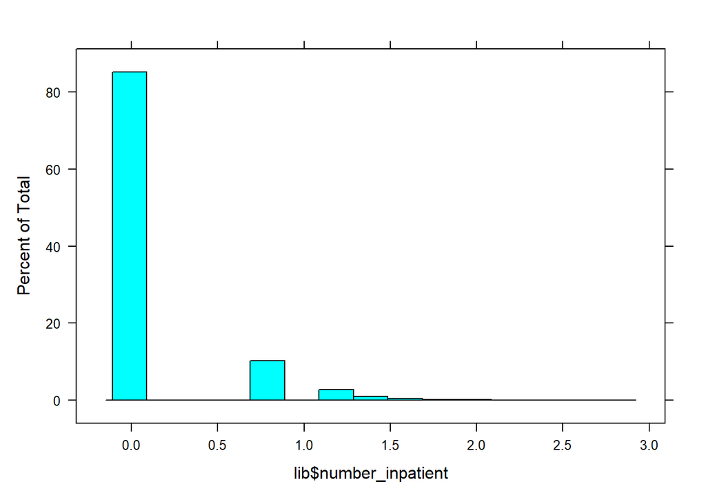

```r
# Low variance is usefull to identify outliers
# correlation would be lower if variance is low.
lib$num_med <- 0
lib$num_changes <- 0
for(key in keys){
  lib$num_med <- ifelse(lib[key] != 0, lib$num_med + 1, lib$num_med)
  lib$num_changes <- ifelse((lib[key] == 1 | lib[key] == 2 | lib[key] == 3), lib$num_changes + 1, lib$num_changes)
}



## Normalize, Remove Outliers, and Standardize Numerical Features
lib$number_inpatient <- log1p(lib$number_inpatient)
lib$number_outpatient <- log1p(lib$number_outpatient)
lib$number_emergency <- log1p(lib$number_emergency)

histogram(lib$number_inpatient)
```

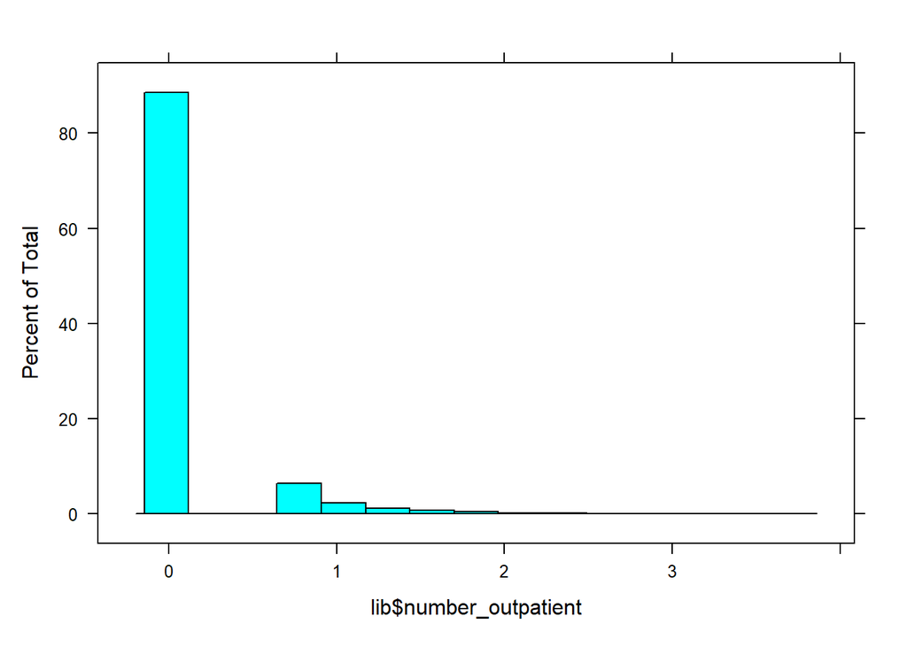

```r
histogram(lib$number_outpatient)
```

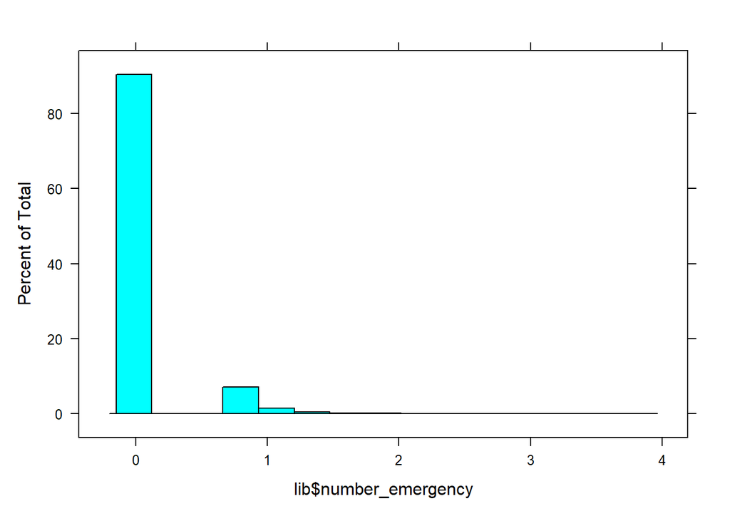

```r
histogram(lib$number_emergency)
```

```r
non_outliers = function(x, zs) {
  temp <- (x - mean(x))/sd(x)
  return(temp < zs)
}



lib <- lib[non_outliers(lib$number_inpatient, 3),]
lib <- lib[non_outliers(lib$number_outpatient, 3),]
lib <- lib[non_outliers(lib$number_emergency, 3),]
lib <- subset(lib, select = -c(number_emergency))



#Normalise skewed features and removing outliers using z-score

cols <- dplyr::select_if(lib, is.numeric)
temp <- scale(dplyr::select_if(lib, is.numeric))
for(col in colnames(cols)){
  lib[,col] <- temp[,col]
}
str(lib)
```

```
## 'data.frame':    17547 obs. of  48 variables:
##  $ encounter_id              : num  -1.34 -1.33 -1.33 -1.32 -1.23 ...
##  $ patient_nbr               : num  -0.945 -0.938 -0.938 -0.934 -1.286 ...
##  $ race                      : chr  "Caucasian" "Caucasian" "Caucasian" "Caucasian" ...
##  $ gender                    : chr  "Female" "Female" "Female" "Male" ...
##  $ age                       : chr  "70" "60" "90" "70" ...
##  $ admission_type_id         : num  -1.1297 0.0569 -1.1297 -1.1297 -1.1297 ...
##  $ admission_type_name       : chr  "Emergency" "Urgent" "Emergency" "Emergency" ...
##  $ discharge_disposition_id  : num  4.4708 -0.4262 -0.4262 -0.193 0.0402 ...
##  $ discharge_disposition_name: chr  "Discharged/transferred to another rehab fac including rehab units of a hospital ." "Discharged to home" "Discharged to home" "Discharged/transferred to another short term hospital" ...
##  $ admission_source_id       : num  0.91 -1.184 0.91 0.91 0.561 ...
##  $ admission_source_name     : chr  " Emergency Room" " Physician Referral" " Emergency Room" " Emergency Room" ...
##  $ time_in_hospital          : num  0.9463 -0.4169 -0.0761 1.9687 2.6503 ...
##  $ payer_code                : chr  "MC" "MC" "MC" "MC" ...
##  $ medical_specialty         : chr  "Orthopedics-Reconstructive" "Nephrology" "Emergency/Trauma" "InternalMedicine" ...
```

[output cut: 34 more lines]

```r
# see c
 # see c
library(dplyr)
# see c
library(GGally)
```

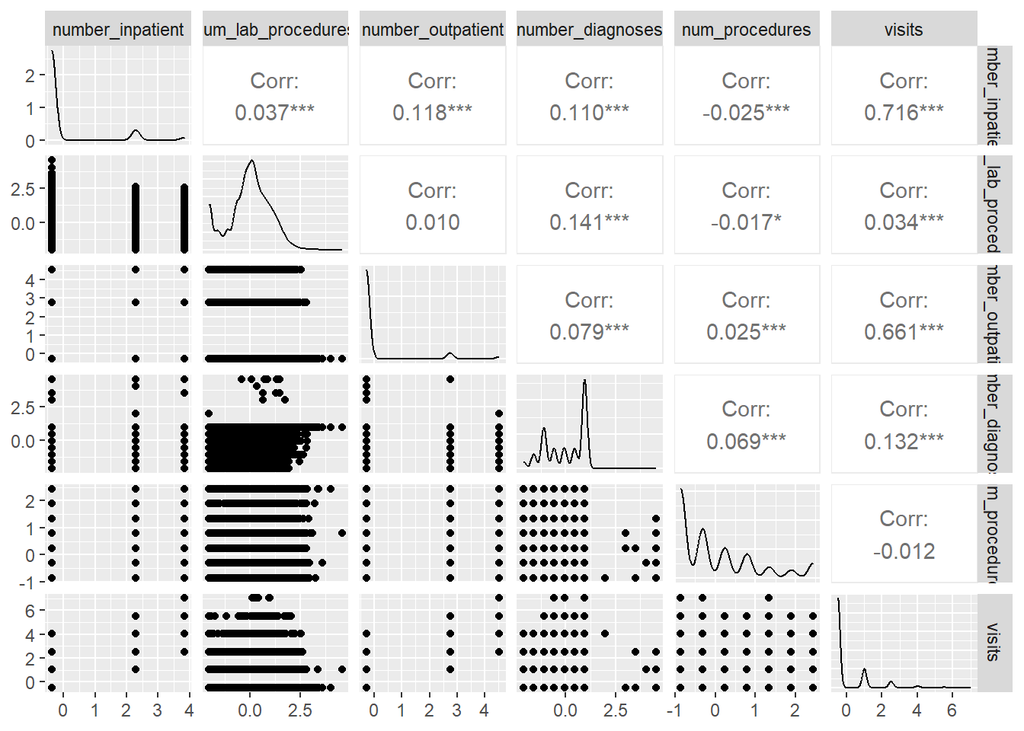

```r
ggpairs(lib, columns = c("number_inpatient","num_lab_procedures","number_outpatient","number_diagnoses",
                         "num_procedures","visits"))
```

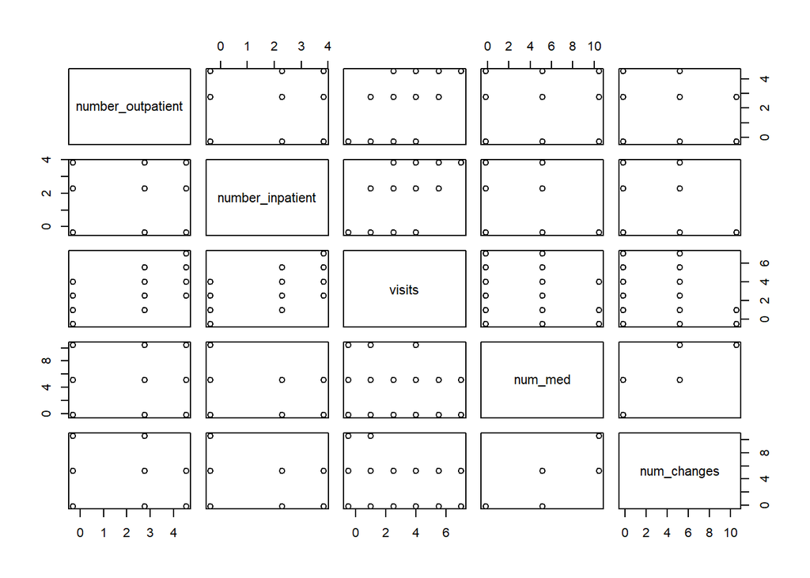

```r
# Change datatype
lib$num_med   <- as.numeric(lib$num_med)
# Change data type
lib$num_changes <- as.numeric(lib$num_changes)

# PLot all the variables

cor <-  lib %>% dplyr::select(number_outpatient,number_inpatient,visits, num_med, num_changes)
plot(cor)
```

```r
library(psych)
```

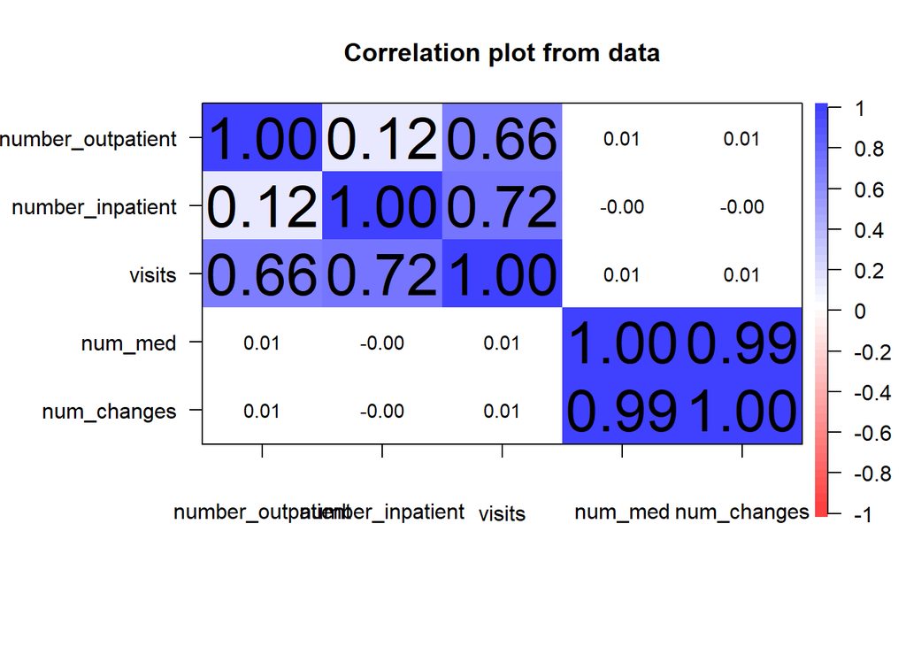

```r
corPlot(cor)
```

```r
# Model development

# Model development

# set seed
set.seed(123)
# turn row into 2 category 1 for readmitted and 0 not readmitted in the prediod of 30 days
lib$readmitted <- case_when(lib$readmitted %in% c(">30","NO") ~ "0",
                              TRUE ~ "1")

# creating  training and test
train_indices <- sample(seq_len(nrow(lib)), 0.7* nrow(lib))
train_data <- lib[train_indices, ]
test_data <- lib[-train_indices, ]

# Fit the logistic regression
model <- glm(readmitted == '1' ~  visits + number_inpatient + number_outpatient  , data = train_data)
summary(model)
```

```
##
## Call:
## glm(formula = readmitted == "1" ~ visits + number_inpatient +
##     number_outpatient, data = train_data)
##
## Deviance Residuals:
##      Min        1Q    Median        3Q       Max
## -0.15409  -0.07546  -0.07546  -0.07546   0.94035
##
## Coefficients:
##                    Estimate Std. Error t value Pr(>|t|)
## (Intercept)        0.080788   0.002454  32.924   <2e-16 ***
## visits             0.005823   0.006218   0.936   0.3490
## number_inpatient   0.012472   0.004732   2.636   0.0084 **
## number_outpatient -0.006891   0.004397  -1.567   0.1171
## ---
## Signif. codes:  0 '***' 0.001 '**' 0.01 '*' 0.05 '.' 0.1 ' ' 1
##
## (Dispersion parameter for gaussian family taken to be 0.07393891)
##
##     Null deviance: 911.04  on 12281  degrees of freedom
## Residual deviance: 907.82  on 12278  degrees of freedom
## AIC: 2872.1
##
## Number of Fisher Scoring iterations: 2
```

```r
predicted_probs <- predict(model, newdata = test_data , type = "response")

# Convert probabilities to binary predictions
predicted_classes <- ifelse(predicted_probs > 0.1, "readmitted", "Not readmitted")
# Convert probabilities to predicted classes
##predicted_classes <- ifelse(predicted_probs > 0.5, "<30", ifelse(predicted_probs > 0.25, "NO", ">30"))


# Display the confusion matrix
confusion_matrix <- table(predicted_classes, test_data$readmitted)
print(confusion_matrix)
```

```
##
## predicted_classes    0    1
##    Not readmitted 4261  327
##    readmitted      594   83
```

```r
# Calculate accuracy
accuracy <- sum(diag(confusion_matrix)) / sum(confusion_matrix)
print(paste("Accuracy:", accuracy))
```

```
## [1] "Accuracy: 0.825071225071225"
```

```r
#Display the predicted labels

pred_model_1 <- test_data
pred_model_1$predictor <- predicted_classes
head(pred_model_1)
```

```
##       encounter_id patient_nbr             race gender age admission_type_id
## 24070    -1.219663   -1.100618        Caucasian Female  30       -1.12965500
## 24138    -1.217350   -1.101954        Caucasian Female  70       -1.12965500
## 24277    -1.212543   -1.180311        Caucasian Female  80       -1.12965500
## 24302    -1.211674   -1.144384        Caucasian   Male  30        0.05693921
## 24315    -1.211539   -1.066458 African American Female  80       -1.12965500
## 24345    -1.210605   -1.447905        Caucasian Female  70        0.05693921
##       admission_type_name discharge_disposition_id discharge_disposition_name
## 24070           Emergency               -0.4262194         Discharged to home
## 24138           Emergency               -0.4262194         Discharged to home
## 24277           Emergency               -0.4262194         Discharged to home
## 24302              Urgent                0.9729211                   Left AMA
## 24315           Emergency               -0.4262194         Discharged to home
## 24345              Urgent               -0.4262194         Discharged to home
##       admission_source_id                       admission_source_name
```

[output cut: 62 more lines]

```r
#evaluation
##3 second model
library(boot)
# Define the logistic regression model
set.seed(123)
logistic_model <- glm(readmitted == "1" ~ visits + number_outpatient  , data = lib)
summary(logistic_model)
```

```
##
## Call:
## glm(formula = readmitted == "1" ~ visits + number_outpatient,
##     data = lib)
##
## Deviance Residuals:
##      Min        1Q    Median        3Q       Max
## -0.16832  -0.07363  -0.07363  -0.07363   0.93571
##
## Coefficients:
##                    Estimate Std. Error t value Pr(>|t|)
## (Intercept)        0.079843   0.002043  39.083  < 2e-16 ***
## visits             0.021064   0.002723   7.735 1.09e-14 ***
## number_outpatient -0.013437   0.002723  -4.934 8.14e-07 ***
## ---
## Signif. codes:  0 '***' 0.001 '**' 0.01 '*' 0.05 '.' 0.1 ' ' 1
##
## (Dispersion parameter for gaussian family taken to be 0.07323046)
##
##     Null deviance: 1289.1  on 17546  degrees of freedom
## Residual deviance: 1284.8  on 17544  degrees of freedom
## AIC: 3930.8
##
## Number of Fisher Scoring iterations: 2
```

```r
# Perform 10-fold cross-validation
cv_results <- cv.glm(lib, logistic_model, K = 10)

##print(cv_results)

# Access accuracy
accuracy2 <- 1 - cv_results$delta[1]
cat("Accuracy:", accuracy2, "\n")
```

```
## Accuracy: 0.9267509
```

```r
# Predict the probabilities of the positive class ("Wins")
predicted_probs2 <- predict(logistic_model, newdata = lib, type = "response")


# Convert probabilities to binary predictions
predicted_labels2 <- predicted_classes <- ifelse(predicted_probs2 > 0.1, "readmitted", "Not readmitted")

# Display results
#print(data.frame(Probabilities = predicted_probs2, Predicted_Labels = predicted_labels2))
at2 <- data.frame(Probabilities = predicted_probs2, Predicted_Labels = predicted_labels2)
head(at2)
```

```
##       Probabilities Predicted_Labels
## 20447    0.07362731   Not readmitted
## 20738    0.07362731   Not readmitted
## 20825    0.07362731   Not readmitted
## 21084    0.07362731   Not readmitted
## 23880    0.07362731   Not readmitted
## 23923    0.07362731   Not readmitted
```

```r
# Display the confusion matrix
confusion_matrix2 <- table(predicted_labels2, lib$readmitted)
print(confusion_matrix2)
```

```
##
## predicted_labels2     0     1
##    Not readmitted 13617  1087
##    readmitted      2529   314
```

```r
# Display the predicted labels
#print(predicted_labels2)
pred_model2 <- lib
pred_model2$predictor <- predicted_labels2
head(pred_model2)
```

```
##       encounter_id patient_nbr      race gender age admission_type_id
## 20447    -1.338575  -0.9452118 Caucasian Female  70       -1.12965500
## 20738    -1.329333  -0.9384905 Caucasian Female  60        0.05693921
## 20825    -1.326727  -0.9376905 Caucasian Female  90       -1.12965500
## 21084    -1.318555  -0.9341307 Caucasian   Male  70       -1.12965500
## 23880    -1.225515  -1.2857602 Caucasian Female  70       -1.12965500
## 23923    -1.224257  -1.0683153 Caucasian   Male  70       -1.12965500
##       admission_type_name discharge_disposition_id
## 20447           Emergency               4.47077231
## 20738              Urgent              -0.42621943
## 20825           Emergency              -0.42621943
## 21084           Emergency              -0.19302935
## 23880           Emergency               0.04016074
## 23923           Emergency               0.04016074
##                                                              discharge_disposition_name
```

[output cut: 69 more lines]

## Limitation

There are still outliers in the data set even we used standard deviation to be removed. Data collected should contains more relevant columns that related that are related to diabetes.

```r
#####################################################
# create a new model logistic model with other predictors
set.seed(123)
logistic_model2 <-glm(readmitted== "1"  ~ age + visits + number_outpatient + max_glu_serum + insulin + diabetesMed , data = lib)
summary(logistic_model2)
```

```
##
## Call:
## glm(formula = readmitted == "1" ~ age + visits + number_outpatient +
##     max_glu_serum + insulin + diabetesMed, data = lib)
##
## Deviance Residuals:
##      Min        1Q    Median        3Q       Max
## -0.19364  -0.09269  -0.07753  -0.05726   0.99242
##
## Coefficients:
##                    Estimate Std. Error t value Pr(>|t|)
## (Intercept)       -0.008688   0.155913  -0.056  0.95556
## age10             -0.006254   0.160276  -0.039  0.96888
## age20              0.039639   0.156814   0.253  0.80045
## age30              0.043047   0.156301   0.275  0.78301
## age40              0.042740   0.156063   0.274  0.78419
## age50              0.047020   0.155999   0.301  0.76311
## age60              0.063696   0.155982   0.408  0.68302
## age70              0.072645   0.155974   0.466  0.64140
## age80              0.078862   0.156000   0.506  0.61320
## age90              0.084925   0.156375   0.543  0.58708
## visits             0.020053   0.002722   7.367 1.82e-13 ***
## number_outpatient -0.012827   0.002724  -4.710 2.50e-06 ***
## max_glu_serum100  -0.082886   0.191010  -0.434  0.66434
## insulin1           0.003591   0.005739   0.626  0.53147
## insulin2           0.014393   0.007116   2.023  0.04312 *
## insulin3           0.018947   0.007150   2.650  0.00806 **
## diabetesMed1       0.024835   0.006368   3.900 9.67e-05 ***
## ---
## Signif. codes:  0 '***' 0.001 '**' 0.01 '*' 0.05 '.' 0.1 ' ' 1
##
## (Dispersion parameter for gaussian family taken to be 0.07290601)
##
##     Null deviance: 1289.1  on 17546  degrees of freedom
## Residual deviance: 1278.0  on 17530  degrees of freedom
## AIC: 3866.9
##
## Number of Fisher Scoring iterations: 2
```

```r
# Perform 10-fold cross-validation
cv_results2 <- cv.glm(lib, logistic_model2, K = 10)

head(cv_results2)
```

```
## $call
## cv.glm(data = lib, glmfit = logistic_model2, K = 10)
##
## $K
## [1] 10
##
## $delta
## [1] 0.07296679 0.07295988
##
## $seed
##   [1]       10403         624  -983674937   643431772  1162448557  -959247990
##   [7]  -133913213  2107846888   370274761 -2022780170  -412390145   848182068
##  [13]  -266662747 -1309507294  1356997179  1661823040  1749531457  -516669426
##  [19]  1042678071 -1279933428  -410084963  1151007674  -895613453  1288379032
##  [25]  -376044615 -1358274522   307686511   101447652  1796216213 -1567696558
```

[output cut: 100 more lines]

```r
# Access accuracy
accuracy3 <- 1 - cv_results2$delta[1]
cat("Accuracy:", accuracy3, "\n")
```

```
## Accuracy: 0.9270332
```

```r
# Predict the probabilities of the positive class ("Wins")
predicted_probs3 <- predict(logistic_model2, newdata = lib, type = "response")


# Convert probabilities to binary predictions
predicted_labels3 <- ifelse(predicted_probs3 > 0.1, "readmitted", "Not readmitted")

# Display results
#print(data.frame(Probabilities = predicted_probs3, Predicted_Labels = predicted_labels3))
at <- data.frame(Probabilities = predicted_probs3, Predicted_Labels = predicted_labels3) %>% arrange(desc(Probabilities))
head(at)
```

```
##       Probabilities Predicted_Labels
## 59841     0.1936381       readmitted
## 36935     0.1919764       readmitted
## 38066     0.1919764       readmitted
## 52957     0.1919764       readmitted
## 54845     0.1919764       readmitted
## 98779     0.1919764       readmitted
```

```r
# Display the predicted labels
#print(predicted_labels3)
pred_model3 <- lib
pred_model3$predictor <- predicted_labels3
head(pred_model3)
```

```
##       encounter_id patient_nbr      race gender age admission_type_id
## 20447    -1.338575  -0.9452118 Caucasian Female  70       -1.12965500
## 20738    -1.329333  -0.9384905 Caucasian Female  60        0.05693921
## 20825    -1.326727  -0.9376905 Caucasian Female  90       -1.12965500
## 21084    -1.318555  -0.9341307 Caucasian   Male  70       -1.12965500
## 23880    -1.225515  -1.2857602 Caucasian Female  70       -1.12965500
## 23923    -1.224257  -1.0683153 Caucasian   Male  70       -1.12965500
##       admission_type_name discharge_disposition_id
## 20447           Emergency               4.47077231
## 20738              Urgent              -0.42621943
## 20825           Emergency              -0.42621943
## 21084           Emergency              -0.19302935
## 23880           Emergency               0.04016074
## 23923           Emergency               0.04016074
##                                                              discharge_disposition_name
```

[output cut: 69 more lines]

```r
# Display the confusion matrix
confusion_matrix3 <- table(predicted_labels3, lib$readmitted)
#print(confusion_matrix3)


# linear regression
model22 <- lm(as.numeric(as.factor(readmitted)) ~ visits + number_outpatient , data = train_data)
summary(model22)
```

```
##
## Call:
## lm(formula = as.numeric(as.factor(readmitted)) ~ visits + number_outpatient,
##     data = train_data)
##
## Residuals:
##      Min       1Q   Median       3Q      Max
## -0.16422 -0.07548 -0.07548 -0.07548  0.93941
##
## Coefficients:
##                    Estimate Std. Error t value Pr(>|t|)
## (Intercept)        1.080710   0.002454 440.350  < 2e-16 ***
## visits             0.019739   0.003285   6.008 1.93e-09 ***
## number_outpatient -0.014609   0.003282  -4.452 8.58e-06 ***
## ---
## Signif. codes:  0 '***' 0.001 '**' 0.01 '*' 0.05 '.' 0.1 ' ' 1
##
## Residual standard error: 0.272 on 12279 degrees of freedom
## Multiple R-squared:  0.002967,   Adjusted R-squared:  0.002805
## F-statistic: 18.27 on 2 and 12279 DF,  p-value: 1.192e-08
```

```r
# Make predictions
predictions5 <- predict(model22, newdata = test_data)

predicted_probs22 <- predict(model22, newdata = test_data , type = "response")

# Convert probabilities to binary predictions
predicted_classes22 <- ifelse(predicted_probs22 > 0.1, "Readmitted", "Not readmitted")
# Calculate RMSE
rmse <- sqrt(mean((as.numeric(as.factor(train_data$readmitted)) - predictions5)^2))
# Evaluate accuracy (you might want to use a suitable metric for regression, e.g., RMSE)
accuracy5 <- sqrt(mean((as.numeric(test_data$readmitted) - predictions5)^2))
accuracy5
```

```
## [1] 1.037928
```

```r
# Display results
print(paste("Root Mean Squared Error (RMSE):", round(accuracy5, 3)))
```

```
## [1] "Root Mean Squared Error (RMSE): 1.038"
```

```r
# Baseline model: Predict the mean of the response variable
baseline_predictions <- rep(mean(as.numeric(train_data$readmitted)), nrow(test_data))

# Calculate RMSE for the baseline model
baseline_rmse <- sqrt(mean((as.numeric(test_data$readmitted) - baseline_predictions)^2))



# Calculate RMSE for the model
model5_rmse <- sqrt(mean((as.numeric(test_data$readmitted) - predictions5)^2))





test_data2 <- test_data
# Compare the RMSE of the baseline model and the new model
print(paste("Baseline RMSE 2:", round(baseline_rmse, 3)))
```

```
## [1] "Baseline RMSE 2: 0.268"
```

```r
print(paste("Model 5 RMSE:", round(model5_rmse, 3)))
```

```
## [1] "Model 5 RMSE: 1.038"
```

```r
# Make predictions on the test set
test_data2$predicted_readmission <- predict(model22, newdata = test_data2)

head(test_data2)
```

```
##       encounter_id patient_nbr             race gender age admission_type_id
## 24070    -1.219663   -1.100618        Caucasian Female  30       -1.12965500
## 24138    -1.217350   -1.101954        Caucasian Female  70       -1.12965500
## 24277    -1.212543   -1.180311        Caucasian Female  80       -1.12965500
## 24302    -1.211674   -1.144384        Caucasian   Male  30        0.05693921
## 24315    -1.211539   -1.066458 African American Female  80       -1.12965500
## 24345    -1.210605   -1.447905        Caucasian Female  70        0.05693921
##       admission_type_name discharge_disposition_id discharge_disposition_name
## 24070           Emergency               -0.4262194         Discharged to home
## 24138           Emergency               -0.4262194         Discharged to home
## 24277           Emergency               -0.4262194         Discharged to home
## 24302              Urgent                0.9729211                   Left AMA
## 24315           Emergency               -0.4262194         Discharged to home
## 24345              Urgent               -0.4262194         Discharged to home
##       admission_source_id                       admission_source_name
```

[output cut: 62 more lines]

```r
test_data_final <- test_data2 %>% arrange(desc(predicted_readmission))

test_data_final$predicted_readmission <- round(test_data_final$predicted_readmission,0)

##test_data_final %>% arrange(predicted_readmission)
accuracy_table <- data.frame(Mult_regress_1 = round(accuracy,3),
                             Mult_regress_2 = round(accuracy2,3),
                             Mult_regress_3 = round(accuracy3,3),
                             log_regress = round(accuracy5,3),
                             baseline_rmse_log = round(baseline_rmse,3))

confusion_matrix22 <- table(predicted_classes22, test_data$readmitted)
print(confusion_matrix22)
```

```
##
## predicted_classes22    0    1
##          Readmitted 4855  410
```

```r
htmlTable( accuracy_table)
```

|  | Mult_regress_1 | Mult_regress_2 | Mult_regress_3 | log_regress | baseline_rmse_log |
| --- | --- | --- | --- | --- | --- |
| 1 | 0.825 | 0.927 | 0.927 | 1.038 | 0.268 |

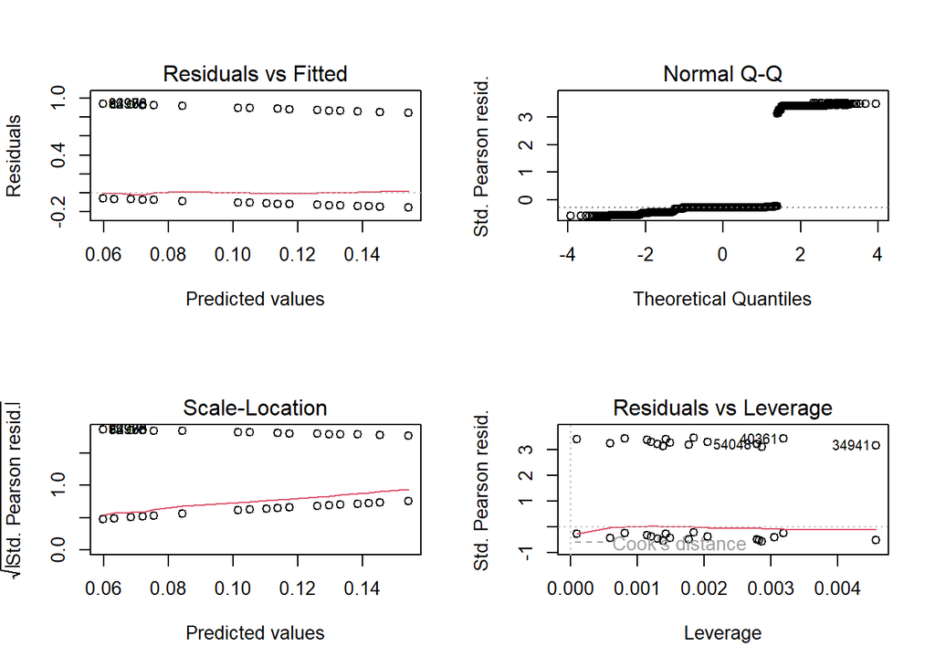

```r
# Plot the residuals
par(mfrow=c(2,2))
plot(model)
```

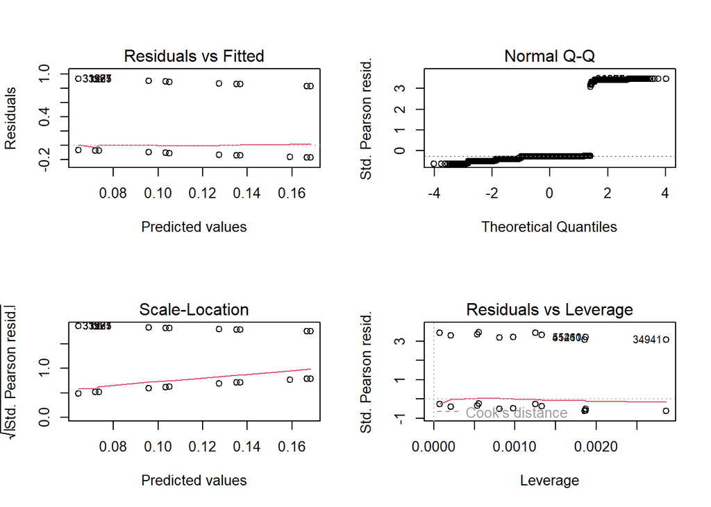

```r
par(mfrow=c(2,2))
plot(logistic_model)
```

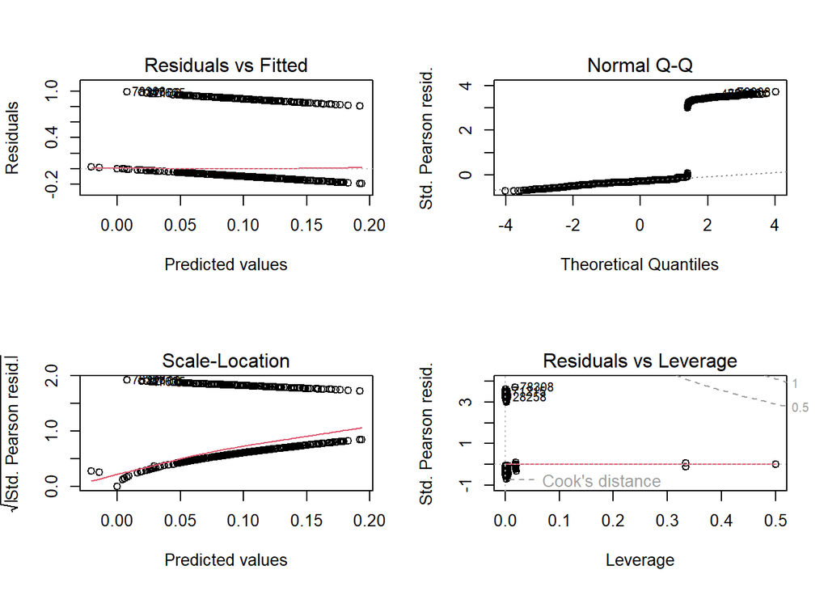

```r
par(mfrow=c(2,2))
plot(logistic_model2)
```

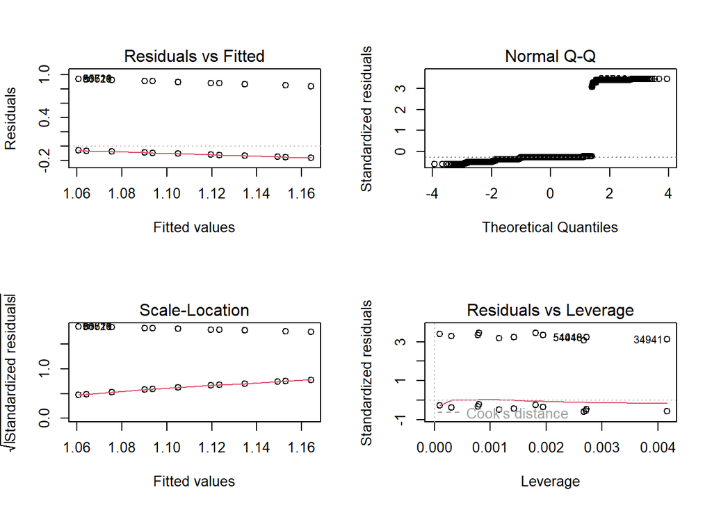

```r
par(mfrow=c(2,2))
plot(model22)
```

## Conclusion

Reducing readmission Rate today is one of the major goals hospitals have in the USA. Hospitals can create models that can predict readmission on within 30 days of the first visit. The process of the creating a model will require data processing skills and statistics. we were able to predict 2529 readmission from patient that weren’t readmitted while predict 314 readmissions. It is important to play with different metrics to improve the model. Data can be changed or reprocessed to a certain need to have a better and optimized model